# Día 5 - Variables aleatorias obtenidas a partir de la variable normal

## Biol. Luis Eloy Homobono Fuentes

luis.homobono@ciencias.unam.mx, [Facebook](https://www.facebook.com/Luis.Eloy.Hom), [Twitter](https://twitter.com/evo_eloy), [GitHub](https://github.com/Luis-Prot)

# Variable Chi-cuadrado (Pearson)

Se escribe variable $\chi^2$ por el hecho de que su función de densidad dependa de un número entero positivo llamado grados de libertad hace que se hable de la distribución $\chi_{k}^2$ con $k$ grados de libertad. Así, existe una variable para cada valor de $k$ mayor o igual a $1$. Esta variable aparece cuando se suman $k$ variables aleatorias independientes con distribución $N(0,1)$, elevadas al cuadrado.

$ \chi _{k}^{2}=X_{1}^{2}+X_{2}^{2}+...+X_{k}^{2},~~~~~~~~con~~X_{i} \in N (0,1)$

El interés de esta distribución radica en su uso para la construcción de intervalos de confianza y realización de contrastes de hipótesis.

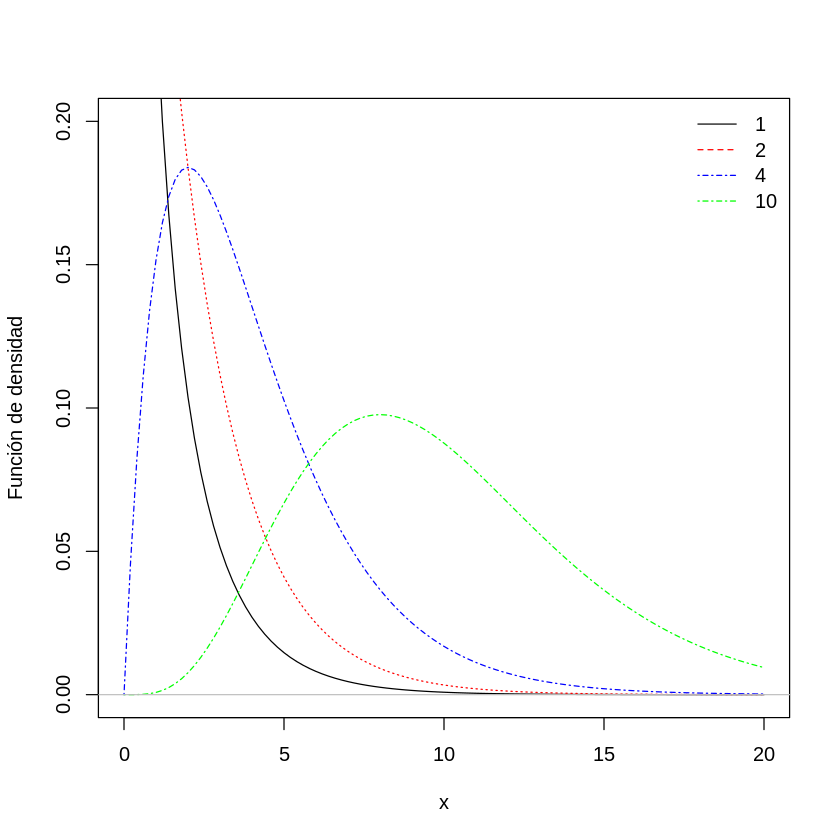

```r
curve(dchisq(x, df = 1), xlim = c(0, 20), ylim = c(0, 0.2), xlab = "x", ylab = "Función de densidad")
curve(dchisq(x, df = 2), col = "red", lty = 3, add = T)
curve(dchisq(x, df = 4), col = "blue", lty = 4, add = T)
curve(dchisq(x, df = 10), col = "green", lty = 4, add = T)
abline(h = 0, col = "gray")
legend("topright", c("1", "2", "4", "10"), col = c("black",
  "red", "blue", "green","yellow"), lty = c(1, 2, 4, 10), bty = "n")
```

# Variable $t$ de Student

Aparece a partir de la distribución normal y la Chi-cuadrado, puesto que si $Z$ es una variable $N(0,1)$, e Y es una variable aleatoria independiente de $Z$, con distribución Chi-cuadrado con $n$ grados de libertad, entonces la variable:

$ t_{n}=\frac{Z}{\sqrt[]{Y/n}}$

es una variable con distribución $t$ con $n$ grados de libertad.

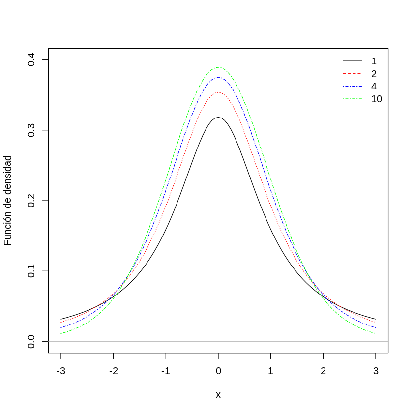

```r
curve(dt(x,df=1),xlim=c(-3,3),ylim=c(0,0.4),xlab='x',ylab='Función de densidad')
curve(dt(x,df=2),col='red', lty=3,add=T)
curve(dt(x,df=4),col='blue',lty=4, add=T)
curve(dt(x,df=10),col='green',lty=4, add=T)
abline(h=0, col="gray")
legend("topright",c("1","2","4","10"),col=c("black","red","blue", "green"),lty=c(1,2,4,10),bty="n")
```

# Caracteristicas de $t$ de Student

La distribución $t$ de Student es una variable aleatoria cuya **función de densidad también tiene forma de campana simétrica** (~$N$)

- **Simétrica, con forma de campana**
- $\mu = 0$.
- **Tiene colas más pesadas** que $N$, lo que significa que el área o probabilidad en los extremos izquierdo y derecho de la curva es mayor que $N$.

> El interés de $t$ es igual que en el caso de la variable $\chi^2$ (para la construcción de intervalos de confianza y realización de contrastes de hipótesis)

# Variable F de Fisher-Snedecor

La distribución $F$ es conocida habitualmente como la distribución $F$ de Snedecor, o distribución $F$ de Fisher-Snedecor.

Su función de densidad es bastante complicada, y depende de dos parámetros $n_1$ y $n_2$ que son sus grados de libertad.

Esta distribución aparece a como un caso particular de la distribución $\chi^2$, puesto que si $\chi$ sigue una distribución $\chi_{n_1}^2$, e $Y$ es otra variable (independiente de $X$) con distribución $χ_{n_2}^2$, entonces la variable $W$ definida como:

$W=\dfrac{X/n_1}{Y/n_2}$

El interés de su estudio corresponde a ser una variable vital en contrastes de hipótesis (**Anovas**).

```r
curve(df(x,df1=1,df2=1),xlim=c(0,5),ylim=c(0,2),xlab='x',ylab='Función de densidad')
curve(df(x,df1=2,df2=1),col='red', lty=3,add=T)
curve(df(x,df1=5,df2=2),col='blue',lty=4, add=T)
curve(df(x,df1=100,df2=1),col='green',lty=4, add=T)
curve(df(x,df1=100,df2=100),col='green',lty=4, add=T)
abline(h=0, col="gray")
legend("topright",c("1","2","4","10"),col=c("black","red","blue", "green"),lty=c(1,2,4,10),bty="n")
```

[output not shown]

# Muestreo aleatorio simple

Se llama así al procedimiento de seleccionar una muestra cumpliendo dos propiedades fundamentales:

- Todos los individuos de la población tienen la misma probabilidad de ser elegidos.
- Todas las muestras del mismo tamaño son igualmente probables.

El motivo de trabajar con un muestreo aleatorio con reeemplazamiento es de naturaleza matemática, ya que permite estudiar propiedades de los distintos procesos de inferencia (decir si lo que se hace está bien o está mal, si una estimación es mejor que otra, etc.).

# Inferencia Estadística

Tiene como objetivo obtener información sobre un parámetro o característica desconocida de la población a partir de una muestra. Para ello podemos:

- Aproximar el parámetro por un valor. Esto se conoce como Estimación puntual.
- Construir un intervalo que, con cierta seguridad, contenga el verdadero valor del parámetro. Esto se llama un **Intervalo de confianza** o estimador por intervalo.
- Verificar si cierta hipótesis sobre el parámetro es coherente con los datos observados. **Contraste de hipótesis**. ($p-value$)

## Se basa en:

- El teorema central del límite.
- La ley de los grandes números de Poisson.

# Teorema central del límite

El teorema central del límite nos permite considerar que una variable sigue una distribución aproximadamente normal cuando sea suma de un conjunto relativamente grande de variables.

- El teorema describe la distribución de la media de una muestra aleatoria proveniente de una población con varianza finita.
- Cuando el tamaño de la muestra es lo suficientemente grande, la distribución de las medias sigue aproximadamente una distribución normal.

**El teorema se aplica independientemente de la forma de la distribución de la población.**

```r
x <- rnorm(10000,0,1)
#plot(density(x))
hist(x,probability = T)
curve(density(x))
```

# Ley de los grandes números de Poisson

La ley de los grandes números dice que “grandes números de individuos, actuando independientemente en un sistema, producen regularidades que no dependen de su coordinación mutua, de manera que es posible razonar sobre la colectividad sin ningún conocimiento detallado de los individuos”.

No se puede predecir el comportamiento individual, pero si el comportamiento promedio.

# Estimación puntual

El objetivo de la estimación puntual es aproximar el valor del parámetro desconocido.

Para ello se utiliza la información de la muestra. Dicha información es gestionada por un estimador.

Algunos estimadores frecuentes son:

- **Media Muestral:** $\overline X = \frac{x_1+...+x_n}{n}$
- **Proporción Muestral:** $\hat p = \frac{x_1+...+x_n}{n}$, siendo $x_1 +...+x_n$ una variable de Bernulli.
- **Varianza Muestral:** $S_{n-1}^2 = \frac{(x_1-\overline x)^2+...+(x_n-\overline x)^2}{n-1}$

# Propiedades de los Estimadores

Una primera propiedad deseable para un estimador es que el centro de la distribución de los valores que puede tomar coincida con el valor del parámetro que queremos aproximar.

- Estimadores insesgados. Un estimador insesgado es aquel cuya media coincide con el valor del parámetro a estimar. **Para saber si no existe sesgo en R podemos hacer lo que se llama una simulación de este proceso.**
- Estimadores consistentes. Un estimador insesgado es consistente cuando su varianza tiende a $0$ si $n$ crece hacia infinito. **La propiedad de consistencia indica que, si tomamos muestras muy grandes, la varianza se hará próxima a cero, es decir que obtendremos siempre valores muy próximos entre sí.**

# Intervalos de confianza (IC)

La estimación puntual siempre aproxima mediante un número el valor de un parametro poblacional o parámetro desconocido pero **no nos indica el error que se comete en dicha estimación**.

Lo razonable en la práctica es adjuntar, junto a la estimación puntual del parámetro, un intervalo que mida el margen de error de la estimación. La construcción de dicho intervalo es el objetivo de la estimación por **intervalos de confianza**.

Un intervalo de confianza para un parámetro con un nivel de confianza $1−\alpha ~~~(0<\alpha<1)$, es un intervalo de extremos aleatorios $(L,U)$, con probabilidad $1−\alpha$, contiene al parámetro en cuestión.

Los valores más habituales del nivel de confianza $1−\alpha$ son **0.9, 0.95 o 0.99** (la confianza es del 90%, 95% o 99%).

### IC

Es un rango plausible de valores en el cual el parámetro poblacional que se está estimando correctamente, Tiene dos carcateristicas:

- Precisión de la estimación según el IC puede ser amplio o estrecho,
- Significancia estadística. Si un IC 95% no incluye el valor nulo, es significativo a nivel $p<0.05$

# Interpretación

[figure not shown]

# Ejercicio

Mediante simulación.

1. Vamos a simular que realizamos encuestas, en este caso preguntando a n=12 personas (si creen en los extraterrestres).
2. De cada muestra podemos obtener una estimación puntual (calculada mediante la proporción en la muestra), y también un intervalo de confianza (que más adelante lo calcularemos).
3. Repite el proceso B=20 veces.

```r
n<-12 # Muestra
B<-20 # Repeticiones

encuesta <- rbinom(n*B,1,0.61)
muestras <- as.data.frame(matrix(encuesta,ncol=n))

# muestras <- as.data.frame(matrix(rbinom(n*B, 1, 0.61), ncol=n)) # elegir probabilidades


rownames(muestras) <- paste("muestra", 1:B, sep="")
colnames(muestras) <- paste("_obs_", 1:n , sep="")

muestras

## Intervalo de confianza
muestras$mean <- rowMeans(muestras[,1:n])

alfa <- 0.05
z <- qnorm(1 - alfa/2)
p <-muestras$mean
muestras$ici <- p - z*sqrt(p*(1-p)/n)
muestras$ics <- p + z*sqrt(p*(1-p)/n)
esta<-0
b=ifelse(0.61<=muestras$ics & 0.61 >= muestras$ici, "SI", "NO")
Resultado<-data.frame(muestras$mean, muestras$ici , muestras$ics, b)
colnames(Resultado)<-c("ptilde", "L", "U", "¿Está o no?")
```

# Contraste de Hipotesis

Forma parte de la Inferencia Estadística fundamentan en la Teoría de la Probabilidad y que tienen por finalidad generalizar los resultados, obtenidos mediante una muestra, a toda una población.

Es decir, se trata de procedimientos para aceptar o rechazar una hipótesis (una afirmación de la realidad) acerca de un parámetro o característica poblacional a partir de una muestra de la población.

# Tipos de Contrastes

Según asuman una determinada distribución de los datos o no.

- Paramétricos
- No Paramétricos

Los contrastes presentan una **hipótesis nula $H_0$ (la que queremos contrastar)** y una **hipótesis alternativa $H_1$ (lo que ocurre si no es cierta la hipótesis nula)**.

Se dice que un contraste es significativo cuando se rechaza H0; y es no-significativo cuando se acepta $H_0$ (o mejor dicho, cuando no rechazamos $H_0$).

La elección de la prueba de contraste que debemos aplicar depende de nuestros datos y las preguntas que nos hacemos sobre ellos.

# Contrastes paramétricos

- Asumen la distribución Normal de los datos.
- Existen contrastes para cualquiera de los parámetros poblacionales: media, varianza, proporción; para 1 o para más muestras.

# Contrastes no paramétricos

- No asumen Normalidad.

# p-Value

El p-valor informa sobre la probabilidad de que el efecto observado (u otro más extremo) pudiera haber aparecido por azar si la hipótesis nula fuera cierta.

$p=P(datos|H_0)$

# Corespondencia entre p-value y IC

Los p-values dependen del tamaño del efecto (señal), del tamaño muestral, y de la variabilidad (ruido)

¿Qué significa realmente que $p<0.05$ o que $p≥0.05$?

# Tipos de contrastes: bilaterales y unilaterales

```r
library(ggplot2)
library(mosaic)
plotDist("t", df = 20, groups = x > -2.085 & x < 2.085,
  type = "h") # Bilateral


plotDist("t", df=20, groups = x > 2.085  , type="h") # Unilateral

plotDist("norm",  groups = x >-1.8  , type="h")
```

# Pasos en un test de hipótesis

- Definir las hipótesis: $H_0$, $H_A$
- Especificar la distribución de $H_0$ $H_0\approx N(\mu,\sigma)$
- Calcular el p-valor observado
- Rechazar o no $H_0$

# Aplicación en R

Contraste

```
x=c(6,6.6,6.5,5.8,7,6.3,6.2,7.2,5.7,6.4,6.5,6.2,6,6.5,7.2,7.3,7.6,6.8,6)
```

```r
x=c(6,6.6,6.5,5.8,7,6.3,6.2,7.2,5.7,6.4,6.5,
    6.2,6,6.5,7.2,7.3,7.6,6.8,6)
mean(x)
sd(x)

pt(-2.3, df=18)  #df son grados de libertad

x=c(6, 6.6, 6.5, 5.8, 7, 6.3, 6.2, 7.2, 5.7, 6.4,
    6.5, 6.2, 6, 6.5, 7.2, 7.3, 7.6, 6.8, 6)

t.test(x, mu=6.8, alternative="less")
```

```r
data(sleep)
sleep
#contraste de una muestra: promedio o media
t.test(sleep$extra)
t.test(sleep$extra,mu=1.4, conf.level = 0.95) #two.sided
t.test(sleep$extra,mu=1,alternative="greater")
t.test(sleep$extra,mu=1,alternative="less")es

shapiro.test(sleep$extra) #para probar si existe normalidad en los datos, es decir, si los datos se distribuyen según una Normal.

wilcox.test(sleep$extra,alternative="less",mu=1)  #sin asumir normalidad
```

# Libreria `ctest`

Existe en R una librería de funciones para realizar contrastes estadísticos, llamada ctest. library(ctest)

| Funciones para contraste | Uso |
| --- | --- |
| binom.test | Test exacto sobre el parámetro de una binomial |
| cor.test | Test de asociaci?n entre muestras apareadas |
| wilcox.test | Test de suma de rangos de Wilcoxon para una y dos muestras |
| prop.test | Test de igualdad de proporciones |
| chisq.test | Test de la chi-cuadrado para datos de conteo |
| fisher.test | Test exacto de Fisher para datos de conteo |
| ks.test | Test de Kolmogorov-Smirnov para ajuste de datos a distribuciones dadas |
| shapiro.test | Test de Shapiro para comprobar ajuste de datos a una distribución normal |
| oneway.test | Test para comprobar la igualdad de medias entre varios grupos de datos |
| var.test | Test para comprobar la igualdad de varianzas entre dos grupos de datos |

# Ejercicio

Tiramos una moneda al aire 600 veces, y nos salen 300 caras.

Y queremos contrastar la hipótesis de que la moneda está equilibrada, esto es, la probabilidad de que p=0.5.

Para ello diremos cuántas veces salió cara y cuántas veces salió cruz:

```
binom.test(c(300,300),p=0.5)
```

```r
## Como el p-valor ha salido 1 (es lo m?s alto posible), no rechazaremos
# la hip?tesis nula. Esto es, daremos por bueno que la moneda estaba equilibrada.
# Observamos que tambi?n obtenemos un intervalo de confianza al 95% para el
# verdadero valor de la probabilidad de obtener cara. Dicho intervalo es
# (0.459, 0.540) en nuestro ejemplo.


binom.test(c(30,100),p=0.5)
   #Otro ejemplo: tiramos la moneda al aire y obtenemos 30 caras y 100 cruces:
    #        Exact binomial test
    #  data:  30 and 130
    #  number of successes = 30, number of trials = 130, p-value = 5.421e-10
    #  alternative hypothesis: true probability of success is not equal to 0.5
    #  95 percent confidence interval:
    #   0.1614375 0.3127614
    #  sample estimates:
    #  probability of success
    #               0.2307692

##En este caso, el p-valor es pr?cticamente cero, lo que quiere decir
# que debemos rechazar la hip?tesis de que la moneda est? equilibrada.
# Como el intervalo de confianza resulta ser (0.16, 0.31), concluiremos
# que la probabilidad de obtener cara para la moneda utilizada est?
# probablemente dentro de dicho intervalo.
```

# Ejercicio

Queremos probar (nuestra hipótesis alternativa) si la proporción de días con nivel de ozono mayor que el permitido es menor o igual que 0.05. Por lo tanto, tenemos que:

Hipótesis nula es $H_0:p>0.05$

Hipótesis alternativa es $H_1:p≤0.05$

- Lleva a cabo un contraste exacto sobre el valor de la probabilidad de éxito en un experimento de Bernoulli. `binom.test()`

```r
binom.test( x = 2, # los 2 días con niveles ozono superiores
            n = 132, # el total de días, los 132
            p = 0.05,
            alternative = "less", # en relación a la H.alternativa
            conf.level = 0.95)

#Con un p-value = 0.03658 menor de 0.05 se rechaza
# la hipótesis nula H0. Nos quedamos con la hipótesis alternativa H1.
# Por lo tanto, podemos concluir que la proporción de días con
# nivel de ozono mayor que el permitido es menor o igual que 0.05
```

# Contraste $\chi^2$

Este contraste se utiliza para tablas de contingencia.

Para disponer de una tabla de contingencia que cruzan dos variables, contando el número de coincidencias según las categorías de ambas variables, y se trata de ver si las variables son o no son independientes.

# Ejemplo.

Supongamos que tenemos una muestra de personas en las que hemos observado dos variables: el color de ojos, que puede ser "claro" y "oscuro", y el color de pelo, que puede ser "rubio" y "moreno".

Entonces hacemos una tabla de contingencia para cruzar dichas características, y aplicamos el test para ver si el "color de ojos" y el "color de pelo" son variables independientes:

Suponemos que los datos han sido recogidos previamente en una variable llamada 'datos':

```
datos
        claro oscuro
rubio     20      2
moreno     3     18
```

En R se utiliza `chisq.test()` para contrastar hipotesis de $chi^2$

```r
color.ojos = c("claro","oscuro","oscuro","oscuro","claro","claro","claro", "oscuro","oscuro","claro","claro","claro","claro","oscuro","oscuro")
color.pelo = c("rubio","moreno","moreno","rubio","moreno","rubio","rubio", "moreno","rubio","moreno","rubio","rubio","rubio","moreno","moreno")
table(color.ojos,color.pelo)
chisq.test(table(color.ojos,color.pelo))
```

# F test

Este test tiene el mismo fin que el test chisq.test, pero otro fundamento, y es útil para muestras pequeáas, caso para el cual chisq.test no es adecuado.

```r
fisher.test(table(color.ojos,color.pelo))
```

## Historia

```
PruebasdeT =  matrix(c(3, 1, 1, 3), nr = 2, dimnames = list(Guess = c("Milk", "Tea"),  Truth = c("Milk", "Tea")))
```

# Gráficos Especializados

Esta es una introducción básica a la graficación y visualización de datos usando la librería `ggplot2`.

```
install.packages("ggplot") # dependencies=TRUE
```

La librería ggplot2 es un paquete de visualización de datos para el lenguaje R que implementa lo que se conoce como la **“Gramática de los Gráficos”**, que no es más que una representación esquemática y en capas.

**No haremos énfasis en el análisis de los datos representados como tal sino en la manera de representarlos** y en la sintaxis que ggplot2 emplea.

```r
library(ggplot2)
```

# Sintaxis `ggplot()`

#### Primera Capa

- Primer argumento es el dataset que contiene la información que se desea graficar. (data =)
- Segundo argumento puede ser el comando aes(), que se refiere a la “estética” del gráfico, es decir, en este caso se especifica o “mapea” cuál variable del conjunto de datos es el que se va a representar en el eje “x”.

#### Segunda Capa

Se agrega una segunda capa usando el operador + , y luego se establece que el gráfico a construir:

- geom_bar(). Gráfico de Barras
- geom_histogram. Histograma
- geom_density. Gráfico de Densidad
- geom_point. Gráfico de Dispersión
- geom_smooth. Linea de Tendencia.
- geom_boxplot. Diagrama de Caja y Bigote
- geom_violin. Diagrama de Violin

# Gráficos de Barras (Barplot)

Uno de los tipos de gráficos más comunes en el anállisis de datos es el gráfico de barras, en el que simplemente se representa con barras de distintas “alturas” las dimensiones de una cantidad numérica comparada con otra. Por ejemplo, tomemos como dataset inicial el mtcars:

```
mtcars
```

ggplot(data = mtcars, aes(x = gear)) + geom_bar()

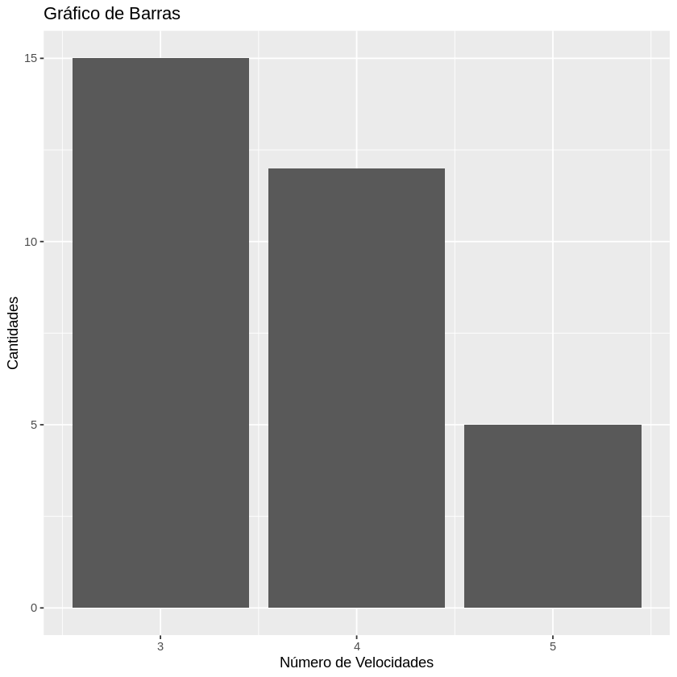

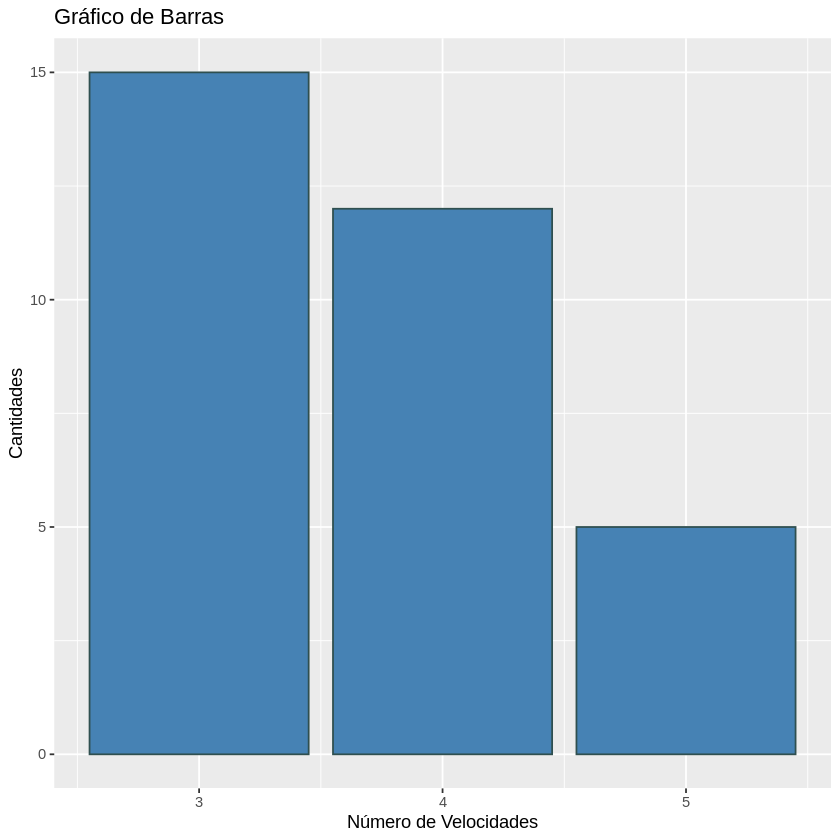

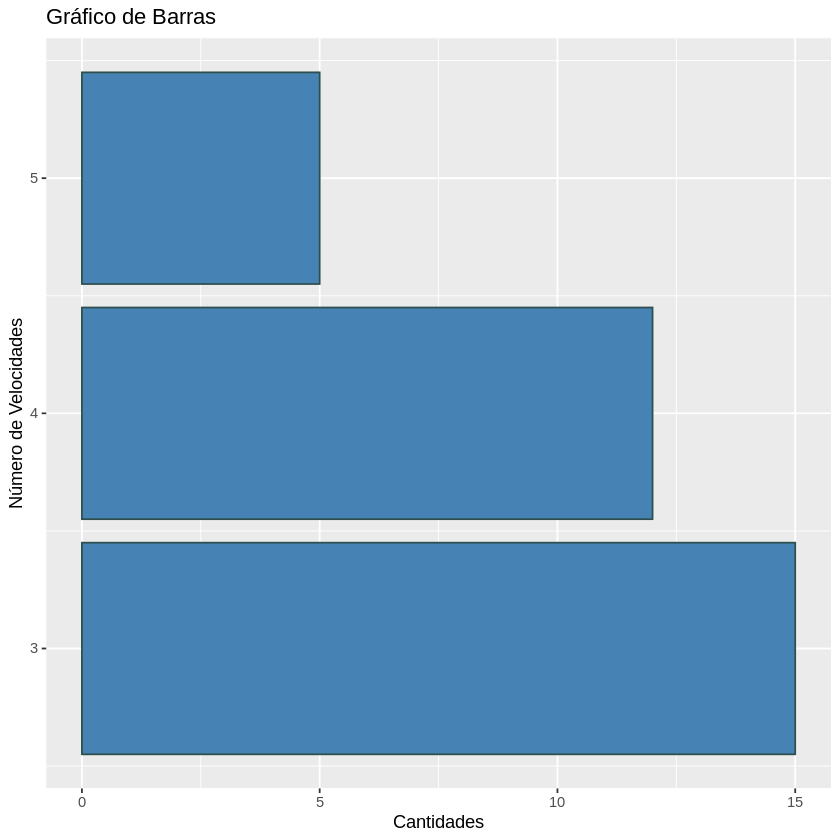

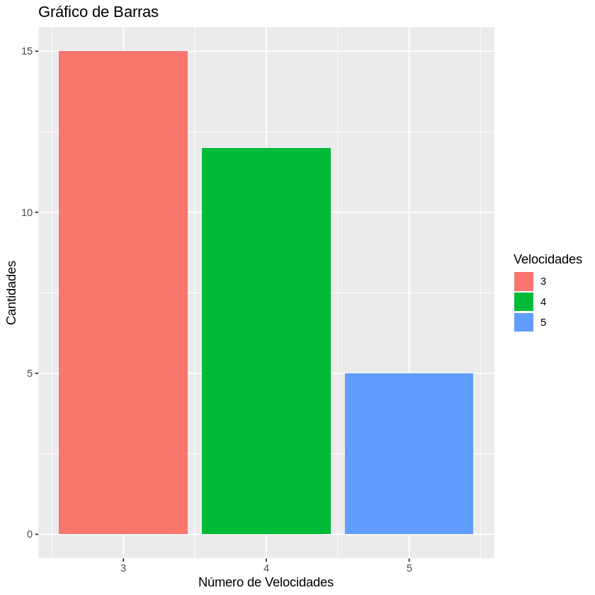

```r
# Grafico de barras
ggplot(data = mtcars, aes(x = gear)) +
  geom_bar() +
  xlab("Número de Velocidades") +
  ylab("Cantidades") +
  ggtitle("Gráfico de Barras")

## Ajuste del color en la segunda capa
ggplot(data = mtcars, aes(x = gear)) +
  geom_bar(color = 'darkslategray', fill = 'steelblue') + # ** #
  xlab("Número de Velocidades") +
  ylab("Cantidades") +
  ggtitle("Gráfico de Barras")

## Ajuste de la orientación de los ejes
ggplot(data = mtcars, aes(x = gear)) +
  geom_bar(color = 'darkslategray', fill = 'steelblue') +
  xlab("Número de Velocidades") +
  ylab("Cantidades") +
  ggtitle("Gráfico de Barras") +
  coord_flip() # ** #

# Ajuste de los datos en grupos
ggplot(data = mtcars, aes(x = gear, fill = as.factor(gear))) + # ** #
  geom_bar() +
  xlab("Número de Velocidades") +
  ylab("Cantidades") +
  ggtitle("Gráfico de Barras") +
  labs(fill = "Velocidades") # ** #
```

# Histograma (Histogram) y Gráfico de Densidad (Density Plot)

Un histograma es un tipo de gráfico de barras en donde la altura de éstas hacen referencia a la frecuencia con la que aparecen los valores que se representan.

Los histogramas son utilizados en la mayoría de las ocasiones para observar la distribución de alguna variable continua, lo que nos permite de una manera sencilla y rápida obtener información como el comportamiento de los datos, tendencias, variabilidad u homogeneidades, entre otros.

A efectos de conocer cómo se implementan los histogramas con ggplot2, vamos a hacer uso esta vez del dataset diamonds.

```
ggplot(diamonds) + geom_histogram(aes(x = carat), fill = 'steelblue') + xlab("Carat") + ylab("Frecuencia") + ggtitle("Distribución de la variable Carat") + theme_minimal()
```

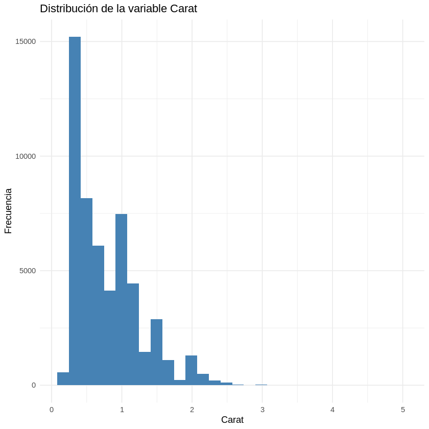

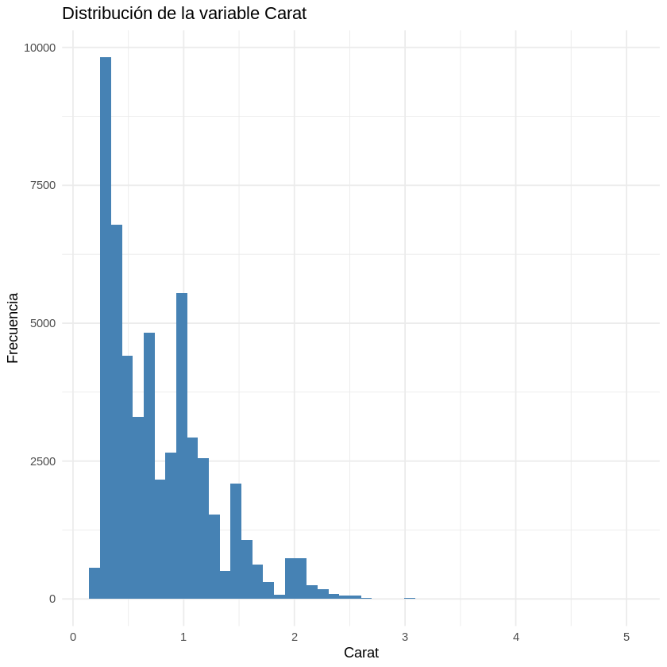

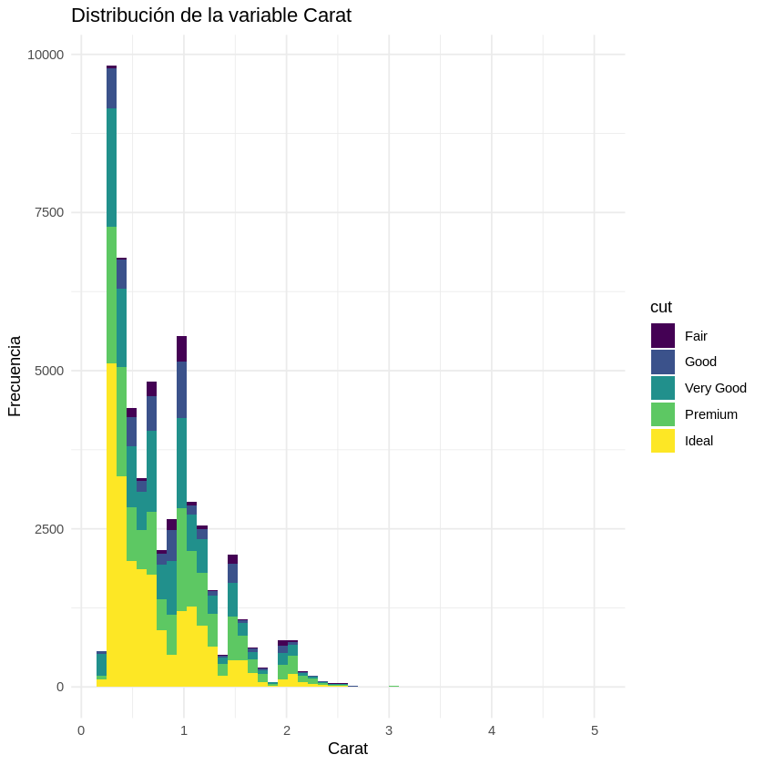

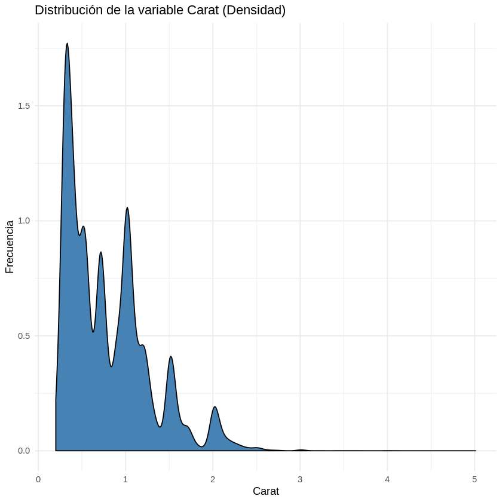

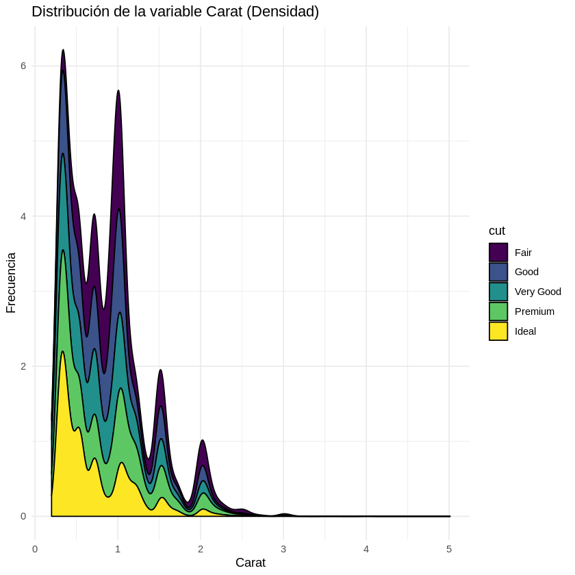

```r
# No bins
ggplot(diamonds) +
  geom_histogram(aes(x = carat), fill = 'steelblue') +
  xlab("Carat") +
  ylab("Frecuencia") +
  ggtitle("Distribución de la variable Carat") +
  theme_minimal()

# Bins
ggplot(diamonds) +
  geom_histogram(bins = 50, aes(x = carat), fill = 'steelblue') + # ancho de bin
  xlab("Carat") +
  ylab("Frecuencia") +
  ggtitle("Distribución de la variable Carat") +
  theme_minimal()

# La información categórica de los diamantes, podemos representarla
ggplot(diamonds) +
  geom_histogram(bins = 50, aes(x = carat, fill = cut)) + # fill cut variable de corte
  xlab("Carat") +
  ylab("Frecuencia") +
  ggtitle("Distribución de la variable Carat") +
  theme_minimal()

# Grafico de densidad
ggplot(diamonds) +
  geom_density(aes(x = carat), fill = 'steelblue') +
  xlab("Carat") +
  ylab("Frecuencia") +
  ggtitle("Distribución de la variable Carat (Densidad)") +
  theme_minimal()

# Densidad por corte categorico
ggplot(diamonds) +
  geom_density(aes(x = carat, fill = cut), position = 'stack') +
  xlab("Carat") +
  ylab("Frecuencia") +
  ggtitle("Distribución de la variable Carat (Densidad)") +
  theme_minimal()
```

# Gráfico de Dispersión (Scatterplot)

El Gráfico de Dispersión o Scatterplot es tal vez uno de los tipos de gráficos matemáticos más empleados. En él, se representan en un eje cartersiano las relaciones entre dos variables generalmente continuas, en la forma de puntos cuyas posiciones en los ejes horizontal y vertical están asociados al valor de cada variable.

Para este ejemplo, usaremos el conjunto de datos `iris`.

```
ggplot(data = iris, aes(x = iris$Sepal.Length, y = iris$Sepal.Width)) + geom_point() + xlab('Largo del Sepalo') +   ylab('Ancho del Sepalo') + ggtitle('Relación entre Ancho y Largo del Sepalo ') + theme_minimal()
```

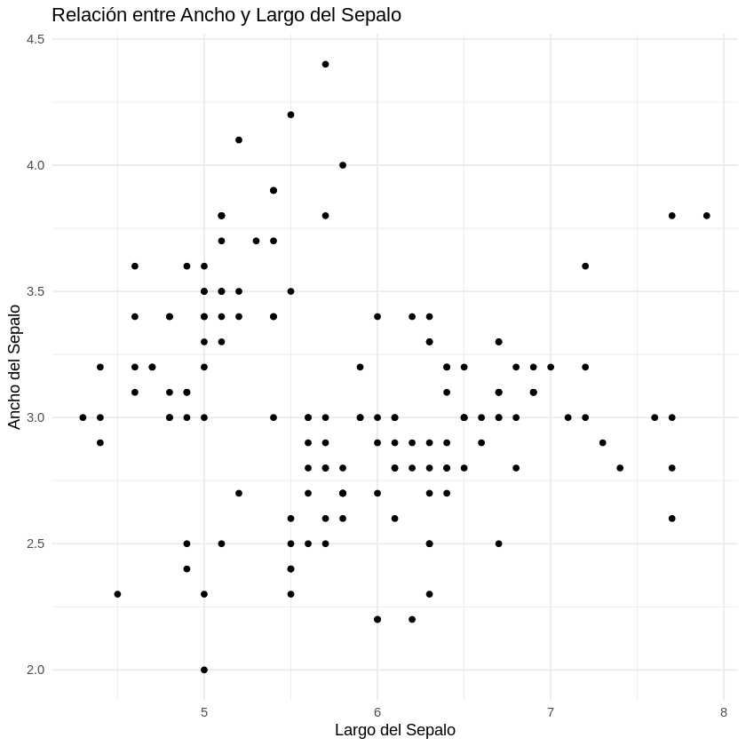

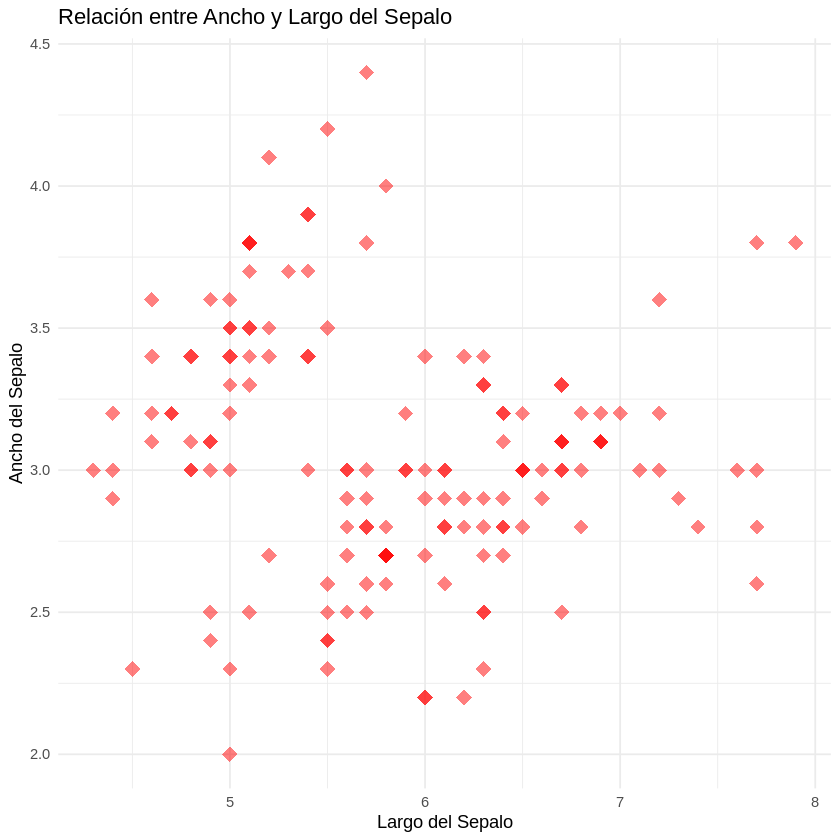

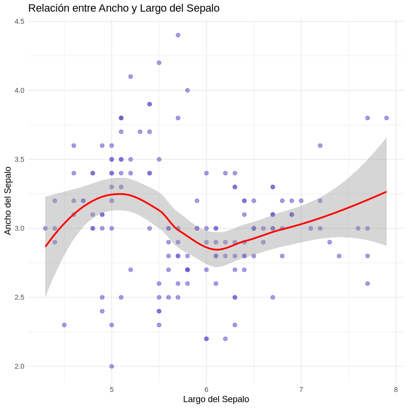

```r
ggplot(data = iris, aes(x = iris$Sepal.Length, y = iris$Sepal.Width)) +
  geom_point() +
  xlab('Largo del Sepalo') +
  ylab('Ancho del Sepalo') +
  ggtitle('Relación entre Ancho y Largo del Sepalo ') +
  theme_minimal()


# Ajuste de color tamaño de las figuras y transparencia alpha
ggplot(data = iris, aes(x = iris$Sepal.Length, y = iris$Sepal.Width)) +
  geom_point(color = 'red', fill = 'red', size = 4, shape = 18, alpha = 0.5) +
  xlab('Largo del Sepalo') +
  ylab('Ancho del Sepalo') +
  ggtitle('Relación entre Ancho y Largo del Sepalo ') +
  theme_minimal()

# Linea de tendencia
ggplot(data = iris, aes(x = iris$Sepal.Length, y = iris$Sepal.Width)) +
  geom_point(color = 'slateblue', size = 2, alpha = 0.6) +
  geom_smooth(color = 'red') +
  xlab('Largo del Sepalo') +
  ylab('Ancho del Sepalo') +
  ggtitle('Relación entre Ancho y Largo del Sepalo ') +
  theme_minimal()
```

# Gráfico de Cajas (Boxplot) y Gráfico de Violín (Violin plot)

El gráfico de cajas es, quizá, uno de los tipos de visualizaciones más complicados de entender, por lo que vamos a elaborar en el ejemplo a fin de presentar la idea de una manera más clara.

```
airquality$Month <- factor(airquality$Month,labels = c("May", "Jun", "Jul", "Aug", "Sep"))

ggplot(airquality, aes(x = airquality$Month, y = airquality$Ozone)) +  geom_boxplot() +  xlab('Meses') +   ylab('Cantidad de Ozono ppm') +  ggtitle('Diagrama de caja ') +   theme_minimal()
```

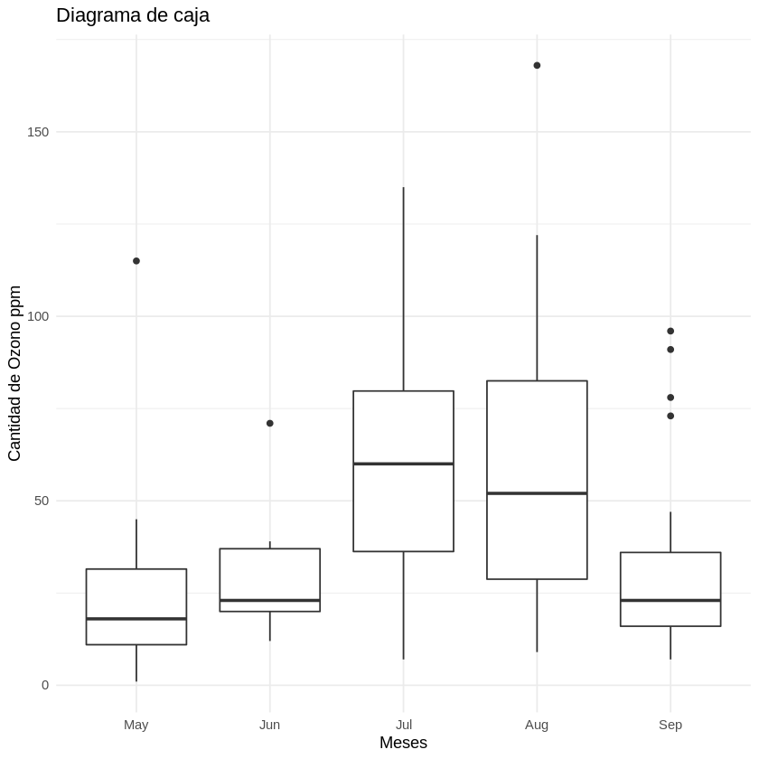

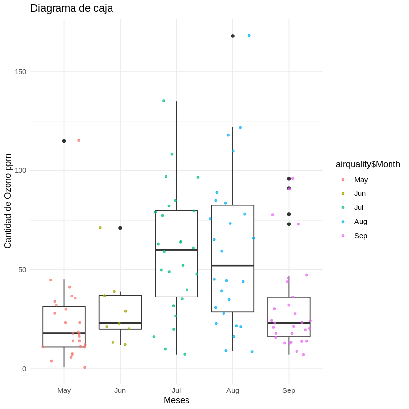

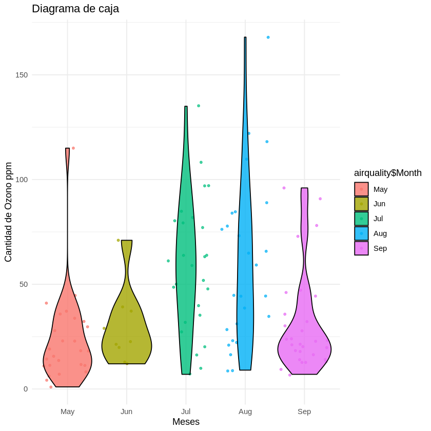

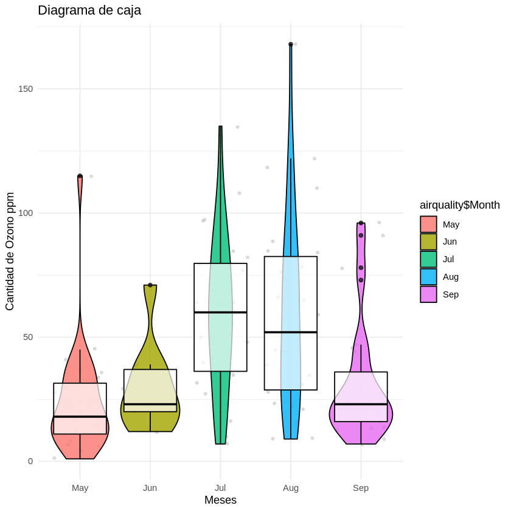

```r
airquality$Month <- factor(airquality$Month,
                           labels = c("May", "Jun", "Jul", "Aug", "Sep"))
ggplot(airquality, aes(x = airquality$Month, y = airquality$Ozone)) +
  geom_boxplot() +
  xlab('Meses') +
  ylab('Cantidad de Ozono ppm') +
  ggtitle('Diagrama de caja ') +
  theme_minimal()

# Jitter
ggplot(airquality, aes(x = airquality$Month, y = airquality$Ozone)) +
  geom_boxplot() +
  geom_jitter(aes(color = airquality$Month), size = 1, alpha = 0.7) +
  xlab('Meses') +
  ylab('Cantidad de Ozono ppm') +
  ggtitle('Diagrama de caja ') +
  theme_minimal()

# Diagrama de Violin
ggplot(airquality, aes(x = airquality$Month, y = airquality$Ozone)) +
  geom_jitter(aes(color = airquality$Month), size = 1, alpha = 0.7) +
  geom_violin(aes(fill = airquality$Month), color = 'black', alpha = 0.8) +
  xlab('Meses') +
  ylab('Cantidad de Ozono ppm') +
  ggtitle('Diagrama de caja ') +
  theme_minimal()

# Todos
ggplot(airquality, aes(x = airquality$Month, y = airquality$Ozone)) +
  geom_jitter(size = 1, color = 'gray', alpha = 0.5) +
  geom_violin(aes(fill = airquality$Month), color = 'black', alpha = 0.8) +
  geom_boxplot(color = 'black', alpha = 0.7) +
  xlab('Meses') +
  ylab('Cantidad de Ozono ppm') +
  ggtitle('Diagrama de caja ') +
  theme_minimal()
```

Esta obra está bajo una [Licencia Creative Commons Atribución 4.0 Internacional](http://creativecommons.org/licenses/by/4.0/).

© Biol. Luis Eloy Homobono Fuentes. 2019.